# Some results figures

Yunyi and Elie

2021-07-22

# Simulation runs

We ran the process 4000 time steps with 5 repeats of each parameter combination and used the last 2000 interations (as a stationary state) and take the average across the replicates for several measures, described below.

Paramater combinations included 10 values of inter-annual predictability x 10 values of risk x 4 values of environmental autocorrelation during dispersal.

In the following three figures, the x-axis is increasing risk, the panels left to right correspond to increasing environmental autocorrelation during dispersal (smaller values = more variable), colors reflect increasing temporal predictability across generations (blue to yellow).

# Figure 1: Genotype

Here, the y-axis is the stationary average genotype of the estimate of the environment, iu.e. the inherited optimism or pessimism. Higher values = more optimistic about the environment. High risk = generally more pessimism, especially when autocorrelation is high, i.e. the predictability is high. The most optimistic scenarios are ones where predictability is LOW and the environment is UNCORRELATED. Optimistic dispersers keep moving (see Figure 3), because they don’t settle until the environment is very good, always believeing there is something better around the corner. In a way, optimism = pickiness. Pessimists (in predictable, autocorrelated environments), think … meh, what’s the point.

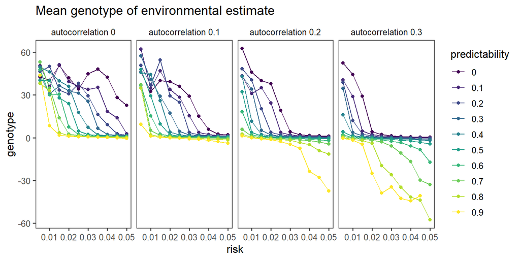

# Figure 2: Knowledge Use

The y-axis here is the ratio between the use of learned knowledge during dispersal and genetic (inherited) knowledge in making the settlement decision. If the number is less than 1 (horizontal dashed line), inherited knowledge is more important that what is learned about the environemnt. At lower risk, there is more movement and more is learned along the way. Inherited knowledge is most useful under a combination of high environemntal autocorrelation (predictable during dispersal) and interannually predictable environments with higher risk leads, i.e. the most pessimistic scenarios.

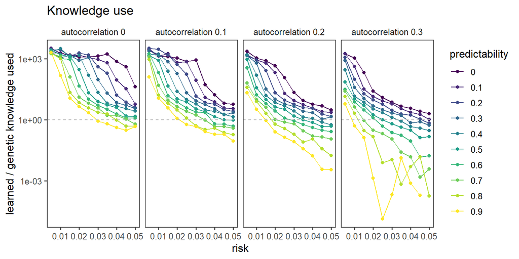

# Figure 3: Total Movement before settlement

Total number of steps before settling. The most optimistic scenarios move most.

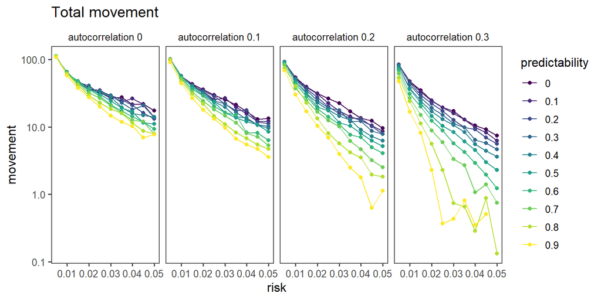